# A new rapid resazurin-based microdilution assay for antimicrobial susceptibility testing of Neisseria gonorrhoeae

Summary statistics

## Introduction

In this file you find summary statistics used in the paper.

## Data description

### Number of unique strains: 124

### Strain composition

Note: reference contains 3 replicates

|  | Azithromycin | Cefixime | Ceftriaxone | Ciprofloxacin | Penicillin | Spectinomycin | Tetracycline | Sum |
| --- | --- | --- | --- | --- | --- | --- | --- | --- |
| **training** | 84 | 84 | 84 | 84 | 84 | 84 | 84 | 588 |
| **validation** | 40 | 40 | 40 | 40 | 40 | 40 | 40 | 280 |
| **Sum** | 124 | 124 | 124 | 124 | 124 | 124 | 124 | 868 |

### EUCAST classification

|  | Azithromycin | Cefixime | Ceftriaxone | Ciprofloxacin | Penicillin | Spectinomycin | Tetracycline | Sum |
| --- | --- | --- | --- | --- | --- | --- | --- | --- |
| **I** | 38 | 0 | 0 | 0 | 37 | 0 | 25 | 100 |
| **R** | 60 | 35 | 10 | 87 | 82 | 7 | 96 | 377 |
| **S** | 26 | 89 | 114 | 37 | 5 | 117 | 3 | 391 |
| **Sum** | 124 | 124 | 124 | 124 | 124 | 124 | 124 | 868 |

### Dose response modelling

|  | Azithromycin | Cefixime | Ceftriaxone | Ciprofloxacin | Penicillin | Spectinomycin | Tetracycline | Sum |
| --- | --- | --- | --- | --- | --- | --- | --- | --- |
| **above limit of detection** | 4 | 0 | 0 | 0 | 7 | 4 | 0 | 15 |
| **quality ok** | 120 | 124 | 124 | 124 | 117 | 120 | 124 | 853 |
| **Sum** | 124 | 124 | 124 | 124 | 124 | 124 | 124 | 868 |

|  | training | validation | Sum |
| --- | --- | --- | --- |
| **above limit of detection** | 6 | 9 | 15 |
| **quality ok** | 582 | 271 | 853 |
| **Sum** | 588 | 280 | 868 |

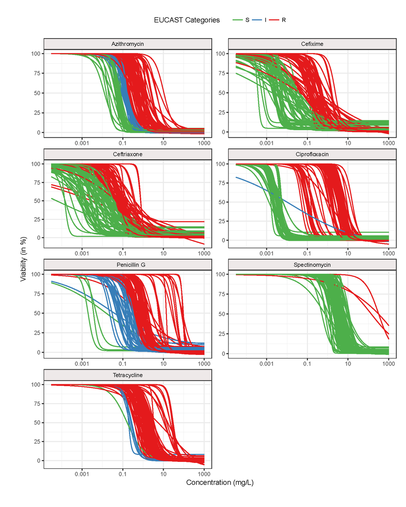

Figure 1. Potency shift of antimicrobials across different strains of N. gonorrhoeae. Dose response curves for all strains and antimicrobials are shown (except samples above limit of detection). Strains that were classified as susceptible according to EUCAST 2016 MIC breakpoints46 were coloured in green, intermediate resistant strains in blue and resistant strains in red. The gradual shift of the potencies (EC50) towards higher concentrations can be observed for all antimicrobials.